# Exploring the BRFSS data

Robert Muwanga

The Behavioral Risk Factor Surveillance System (BRFSS) serves as the United States’ premier system of health-related telephone surveys that collect state data about U.S. residents regarding their health-related risk behaviors, chronic health conditions, and use of preventive services. BRFSS collects data in all 50 states as well as the District of Columbia and three U.S. territories. BRFSS completes more than 400,000 adult interviews each year, making it the largest continuously conducted health survey system in the world.

This assignment looks to using data from this system to test the students’ understanding of basic statistics and probability theory in relation to the Introduction to Probability and Data course offered by Duke University through the Coursera platform. This course leverages on pre-cleaned data across 330 variables and 491775 observations. This data is explored in Part 3 of this document and used to answer 3 key inferential questions outlined in Part 2.

## Setup

### Load packages

We load the packages that will help with our data analysis. In this case, we mainly focus on two:

- *ggplot2* for data visualization; and
- *dplyr* for data manipulation.

```r
library(ggplot2)
library(dplyr)
library(forcats)
```

With the assumption that the data is relatively clean, additional packages are not needed to satisfy the requirements of this exercise.

### Load data

We follow through with loading the cleaned data file. Please note that the expectation is that the Rmarkdown document and the data file are in the same folder.

```r
load("brfss2013.RData")
```

As a brief summary, we can see that the file consists of:

- `330` number of variables of initial interest.
- `491775` number of observations.

## Part 1: Data

From the BRFSS Data User Guide located [here](https://www.cdc.gov/brfss/data_documentation/pdf/UserguideJune2013.pdf), one can observe that the data collection process involved states obtaining sample phone numbers from the CDC, and work with a statistician to review the data collection methodology and its implementation. Two different sampling techniques are used depending on the nature of the phone number:

- **Landline Telephone Numbers** use Disproportionate Stratified Sampling (DSS). Given individuals in a given household can share a phone number, this method helps to minimize bias by grouping (“stratifying”) individuals by household and subsequently randomly select eligible adults within each strata.
- **Cellular Telephone Samples** uses Simple Random Sampling with the assumption that each individual has a personal phone number which they do not share. Each individual has an equally likely chance of being selected and individuals that may have moved out-of-state have their feedback moved to the respective state, that is, each state will only maintain information that is relevant to the state at the time of data collection.

Given that the data collection samples from a larger population (national citizenry), generalizability would most likely define the scope of inference for this data set. Sound generalizability requires data on large populations, and quantitative research provides the best foundation for producing broad generalizability.

Furthermore, as this dataset is an observational study rather than experimental (with participants not being randomly assigned to groups), causal relationships cannot be built. At best, only correlations between variables can be shown.

## Part 2: Research questions

**Research quesion 1:** *Is there a correlation between BMI and Health Care Cover?*

With the change of global diets to more processed foods, it would be interesting to discover whether there is a positive correlation between BMI and health care cover to provide a basis for further research into the influence of co-variants (e.g. weight) and its impact to the healthcare system.

**Research quesion 2:** *Does education level influence the number of children within a household?*

The general assumption is that those who possess a higher level of education are more career driven and as such are less likely to have larger families.

**Research quesion 3:** *Is there a relationship between fruit and vegetable consumption with BMI?*

The interest would be in assessing whether there is a correlation between fruit and vegetable consumption by BMI, that is, do individuals with lower BMI eat higher proportions of fruit and vegetables?

## Part 3: Exploratory data analysis

**Research quesion 1:** - *Is there a correlation between BMI and Health Care Cover?*

We shall use the two categorical variable *X_bmi5cat* and *hlthpln1* to see whether there is a relationship.

- *X_bmi5cat* : Computed Body Mass Index Categories
- *hlthpln1* : Have Any Health Care Coverage

```r
data <- brfss2013 %>% select(X_bmi5cat, hlthpln1, X_state)
data %>% select(-X_state) %>% table %>% prop.table * 100
```

```
##                hlthpln1
## X_bmi5cat              Yes         No
##   Underweight    1.5327655  0.2392788
##   Normal weight 29.5622643  3.7173446
##   Overweight    32.2333843  3.7117348
##   Obese         25.5665881  3.4366397
```

```r
data_q1 <- data %>%
  group_by(X_bmi5cat, X_state) %>%
  summarize('n' = n())
```

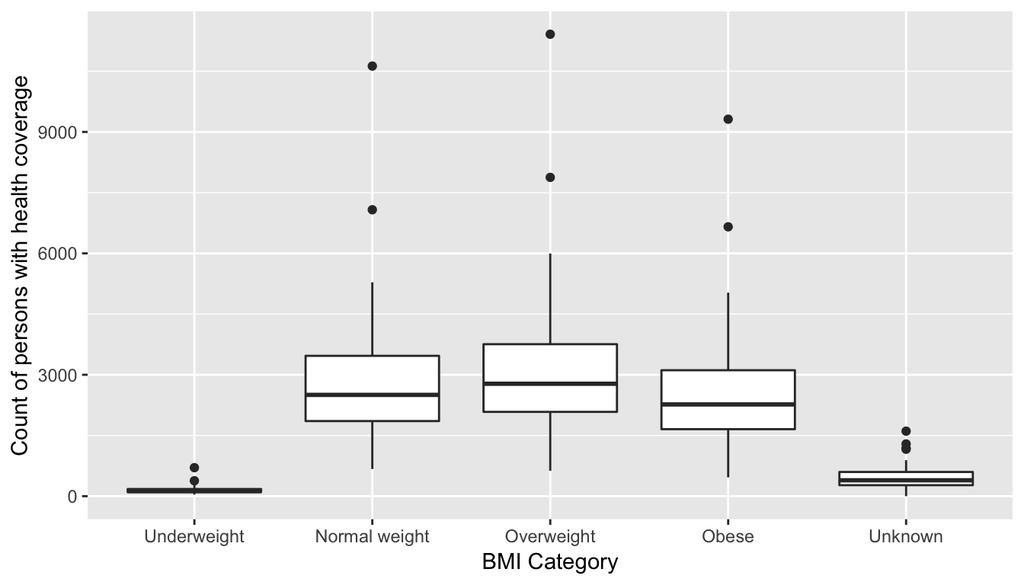

```r
data_q1$X_bmi5cat <- as.character(data_q1$X_bmi5cat) %>%
  sapply(FUN = function(x) if_else(is.na(x), "Unknown", x)) %>%
  factor(levels = c('Underweight', 'Normal weight', 'Overweight', 'Obese', 'Unknown'))

data_q1 %>% ggplot(aes(X_bmi5cat, n)) +
  geom_boxplot() +
  xlab('BMI Category') +
  ylab('Count of persons with health coverage')
```

The boxplot shows that the median coverage is lowest for those classified as Underweight. On first impression, it could presume that those that are underweight view themselves as healthy and have no need for coverage. But a further assessment will be needed to be done to verify such a causal claim and, as we stated before, causal relationships cannot be established with this dataset.

**Research quesion 2:** - *Does education and income levels influence the number of children within a household?*

```r
data <- brfss2013 %>% select(X_educag, children, income2, X_state)
data$X_educag <- forcats::fct_explicit_na(data$X_educag)
data$income2 <- forcats::fct_explicit_na(data$income2)
data %>% group_by(X_educag) %>% summarize('n' = n())
```

```
## # A tibble: 5 x 2
##   X_educag                                        n
##   <fct>                                       <int>
## 1 Did not graduate high school                42213
## 2 Graduated high school                      142968
## 3 Attended college or technical school       134196
## 4 Graduated from college or technical school 170118
## 5 (Missing)                                    2280
```

Let’s visualize this:

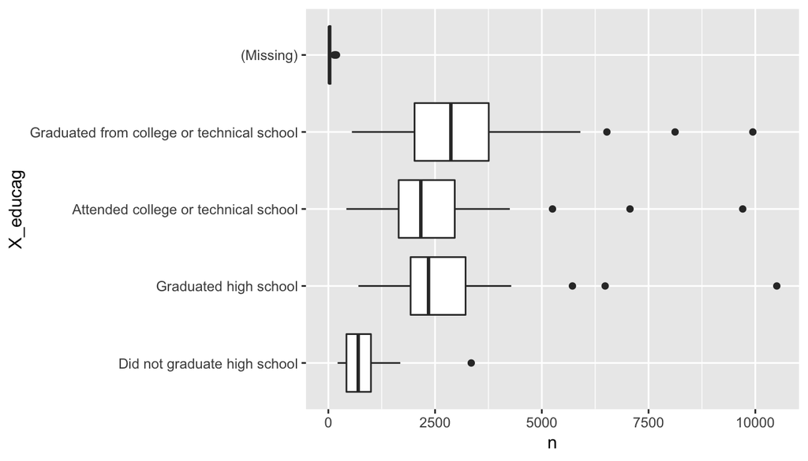

```r
data %>% group_by(X_educag, X_state) %>% summarize('n' = n()) %>%
  ggplot(aes(X_educag, n)) + geom_boxplot() + coord_flip()
```

**Research quesion 3:** - *Is there a relationship between fruit and vegetable consumption with BMI?*

General assumption is that those that consume more fruit and vegetable tend to have a lower BMI score. We can quickly see if such a positive correlation relationship exists and we shall use *X_frutsum*, *X_vegesum* and *X_bmi5* variables.

Let’s look at the comparison between fruit consumption and BMI.

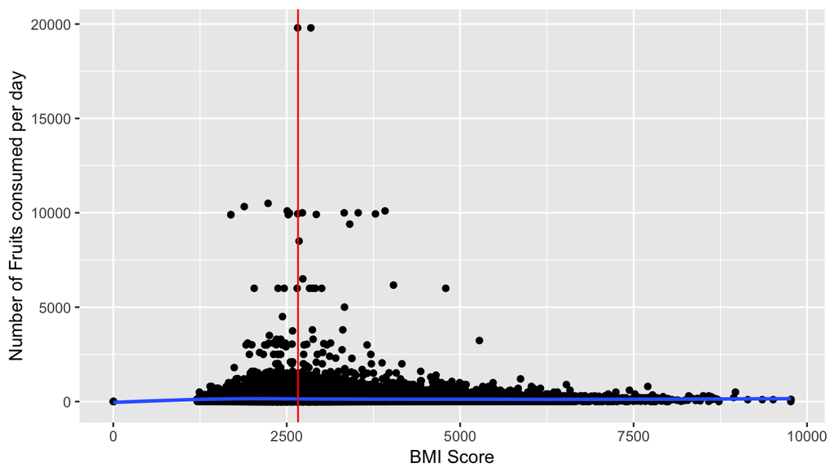

```r
data <- brfss2013 %>%
  select(X_frutsum, X_vegesum, X_bmi5)

data %>%
  ggplot(aes(x = X_bmi5, y = X_frutsum)) +
  geom_point() +
  geom_smooth() +
  geom_vline(xintercept = median(data$X_bmi5, na.rm = T), col = 'red') +
  xlab('BMI Score') +
  ylab('Number of Fruits consumed per day')
```

From the above graph, we can see that there is almost no correlation between the amount of fruits consumed and the BMI, although those close to the median BMI (the red line) have a number of outliers.

Looking at the relationship between BMI and vegetable consumption, the result is almost the same.

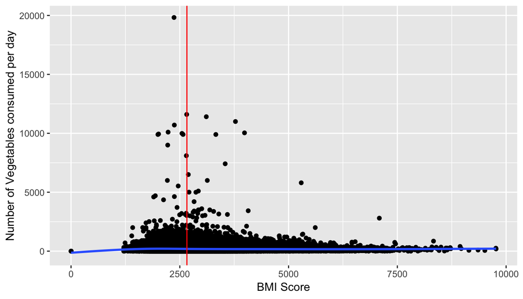

```r
data %>%
  ggplot(aes(x = X_bmi5, y = X_vegesum)) +
  geom_point() +
  geom_smooth() +
  geom_vline(xintercept = median(data$X_bmi5, na.rm = T), col = 'red') +
  xlab('BMI Score') +
  ylab('Number of Vegetables consumed per day')
```